# MAT 217: Homework 2

2026-08-19

```r
library(hanoverbase)
```

# INTRODUCTION

In Homework 1, we practiced opening a dataset, identifying cases and variables, and making a simple plot. In this homework, we will focus on summarizing and visualizing one quantitative variable.

We will use the dataset `in09_2024_county_summary_with_turnout_and_demographics.csv`, which you can find in the `data` folder. Each row represents one county that appears in the 2024 Indiana District 9 U.S. House election data. The dataset is renamed `county2024` for this homework.

Our main variable of interest is `county_2024_median_household_income`, which records the median household income for each county in dollars.

```r
county2024 <- read_csv("../../../data/in09_2024_county_summary_with_turnout_and_demographics.csv")
```

# Question 1

## Part 1a

> ANSWER:

## Part 1b

The variable `county_2024_median_household_income` is quantitative. Is it discrete or continuous? Briefly explain your answer.

> ANSWER:

## Part 1c

Use the code block below to display only the county name and the median household income variable.

```r
county2024 |>
  select(county_name, county_2024_median_household_income)
```

```
## # A tibble: 18 × 2
##    county_name county_2024_median_household_income
##    <chr>                                     <dbl>
##  1 Bartholomew                               79901
##  2 Brown                                     78528
##  3 Clark                                     74214
##  4 Dearborn                                  84735
##  5 Decatur                                   69783
##  6 Floyd                                     79704
##  7 Franklin                                  78074
##  8 Harrison                                  74475
##  9 Jackson                                   70262
## 10 Jefferson                                 64577
## 11 Jennings                                  69322
## 12 Lawrence                                  66468
## 13 Monroe                                    65868
## 14 Ohio                                      70392
## 15 Ripley                                    70573
## 16 Scott                                     56352
## 17 Switzerland                               65343
## 18 Washington                                64641
```

Which county has the lowest median household income? Which county has the highest median household income?

> ANSWER:

# Question 2

## Part 2a

Use the `summary()` function to find the minimum, first quartile, median, mean, third quartile, and maximum of `county_2024_median_household_income`.

```r
summary(county2024$county_2024_median_household_income)
```

```
##    Min. 1st Qu.  Median    Mean 3rd Qu.    Max.
##   56352   66018   70327   71290   77174   84735
```

Record the following values:

- Minimum:
- Q1:
- Median:
- Mean:
- Q3:
- Maximum:

> ANSWER:

## Part 2b

The mean and median are both measures of center. Which one is larger for this variable? Are they close together or far apart?

> ANSWER:

## Part 2c

Based on the mean and median, what does this suggest about the shape of the distribution? Do not overstate your conclusion; this is just an initial clue.

> ANSWER:

# Question 3

## Part 3a

Make a histogram of county median household income.

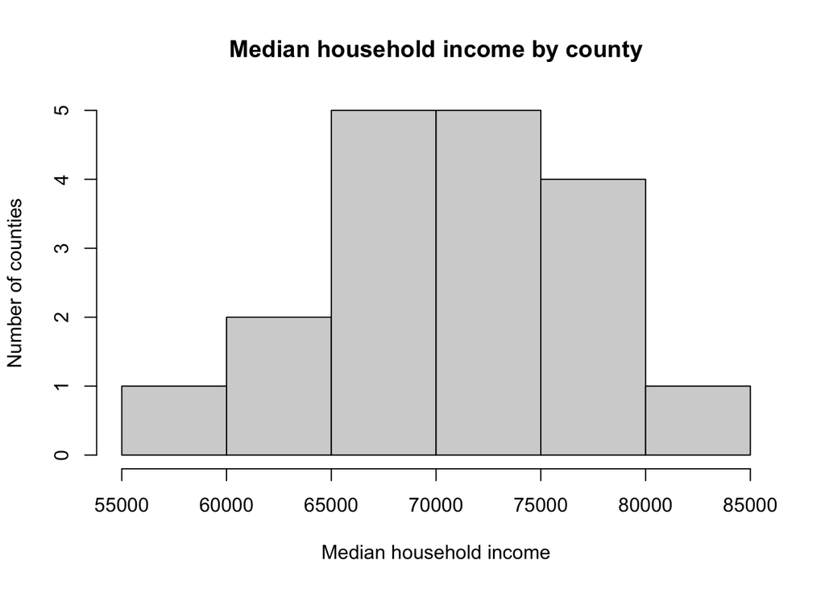

```r
hist(county2024$county_2024_median_household_income,
     main = "Median household income by county",
     xlab = "Median household income",
     ylab = "Number of counties")
```

Describe the shape of the histogram. You may want to comment on where most counties are located and whether the distribution looks roughly symmetric, skewed, or unusual in some other way.

> ANSWER:

## Part 3b

Try changing the number of breaks in the histogram. Run the code below, then compare this histogram with the one from Part 3a.

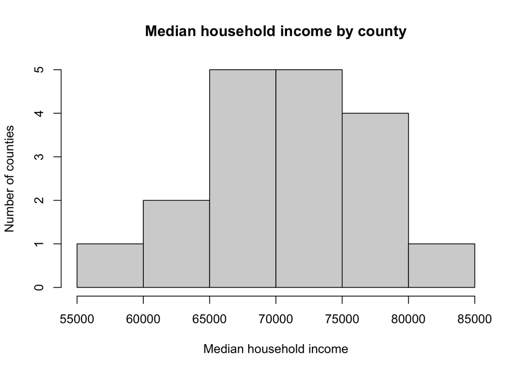

```r
hist(county2024$county_2024_median_household_income,
     breaks = 8,
     main = "Median household income by county",
     xlab = "Median household income",
     ylab = "Number of counties")
```

What changed when you used more breaks? Did your overall interpretation of the distribution change?

> ANSWER:

# Question 4

## Part 4a

Make a boxplot of county median household income.

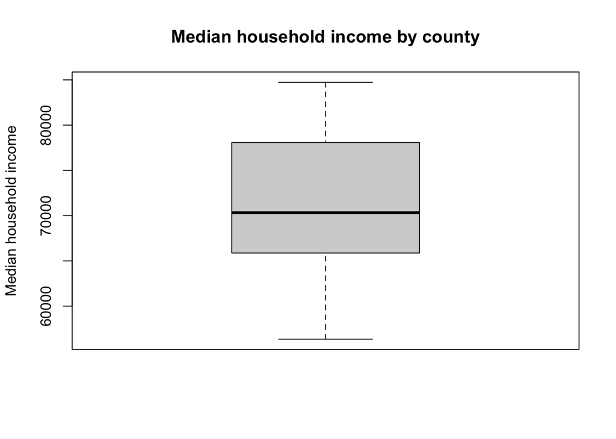

```r
boxplot(county2024$county_2024_median_household_income,
        main = "Median household income by county",
        ylab = "Median household income")
```

Use the boxplot to describe the center, spread, and any possible unusual values.

> ANSWER:

## Part 4b

Use the five-number summary from Question 2 to calculate the interquartile range.

IQR = Q3 - Q1

Show your work.

> ANSWER:

## Part 4c

Use the 1.5 x IQR rule to check for potential outliers.

Lower fence = Q1 - 1.5 x IQR

Upper fence = Q3 + 1.5 x IQR

Show your work. According to this rule, are there any potential outliers?

> ANSWER:

# Question 5

## Part 5a

Sort the counties from lowest to highest median household income.

```r
county2024 |>
  arrange(county_2024_median_household_income) |>
  select(county_name, county_2024_median_household_income)
```

```
## # A tibble: 18 × 2
##    county_name county_2024_median_household_income
##    <chr>                                     <dbl>
##  1 Scott                                     56352
##  2 Jefferson                                 64577
##  3 Washington                                64641
##  4 Switzerland                               65343
##  5 Monroe                                    65868
##  6 Lawrence                                  66468
##  7 Jennings                                  69322
##  8 Decatur                                   69783
##  9 Jackson                                   70262
## 10 Ohio                                      70392
## 11 Ripley                                    70573
## 12 Clark                                     74214
## 13 Harrison                                  74475
## 14 Franklin                                  78074
## 15 Brown                                     78528
## 16 Floyd                                     79704
## 17 Bartholomew                               79901
## 18 Dearborn                                  84735
```

Pick one county near the low end, one county near the middle, and one county near the high end. Record their names and median household incomes.

> ANSWER:

## Part 5b

Based only on the summary and graphs you made in this homework, what can you say about the distribution of median household income across these counties?

In future homework, we will compare variables such as income, turnout, and vote share. For now, focus only on describing the income variable itself.

> ANSWER:

# OPTIONAL EXPLORATION

Choose a different quantitative variable from the dataset, such as `county_2024_poverty_rate`, `county_turnout_rate`, or `total_votes`.

Compare this new variable with `county_2024_median_household_income`. Which variable has more spread? Which one is easier to describe from its graph?

> ANSWER:

# Question 6

1. Knit the document and submit the HTML file on Canvas.
2. Remember to record your individual reflection from this homework in the observation-log.